# Homework 08

The former kernel-tuning question has moved to Homework 09.

Solutions for Questions 1 and 2 will be available after Monday, October 19, 2026. No solution will be provided for Question 3.

For Questions 1 and 2, use either R or Python.

## Question 1: Boundary and margin

Use `margin-geometry-20.csv` from the combined ZIP, which contains 20 observations with predictors $x_1,x_2$ and class labels $y\in\{-1,1\}$. Consider the score

$$f(x)=0.8x_1+0.6x_2.$$

Since $\|(0.8,0.6)\|_2=1$, the lines $f(x)=\pm1$ are each a distance 1 from the decision boundary $f(x)=0$.

1. Calculate the distance from every observation to the decision boundary and its functional margin $yf(x)$. In a table, report these values and whether each observation is inside, on, or beyond the margin for its class. Compare $yf(x)$ with 1 to make this distinction.

```r
data <- read.csv("C:/Users/kates/.vscode/stat432-fall2026/homework/week-08/data/margin-geometry-20.csv")
data$f_x <- 0.8 * data$x1 + 0.6 * data$x2
data$functional_margin <- data$y * data$f_x

# Calculate the distance to the decision boundary
data$distance <- abs(data$f_x)

# Classify each observation relative to its class margin
data$margin_status <- ifelse(
  data$functional_margin < 1, "Inside",
  ifelse(data$functional_margin == 1, "On", "Beyond")
)

# Identify misclassified observations
data$misclassified <- data$functional_margin < 0

# Table
results <- data.frame(
  Observation = data$obs,
  x1 = data$x1,
  x2 = data$x2,
  y = data$y,
  Distance = data$distance,
  Functional_Margin = data$functional_margin,
  Margin_Status = data$margin_status
)

print(results)
```

```
   Observation    x1    x2  y Distance Functional_Margin Margin_Status
1            1  0.68  0.76  1     1.00              1.00            On
2            2  1.80 -0.15  1     1.35              1.35        Beyond
3            3  1.38  0.66  1     1.50              1.50        Beyond
4            4  0.88  1.66  1     1.70              1.70        Beyond
5            5  0.62  2.34  1     1.90              1.90        Beyond
6            6  2.78 -0.04  1     2.20              2.20        Beyond
7            7  1.86  1.52  1     2.40              2.40        Beyond
8            8  0.50  0.40  1     0.64              0.64        Inside
9            9  0.10  0.20  1     0.20              0.20        Inside
10          10 -0.40  0.20  1     0.20             -0.20        Inside
11          11 -0.92 -0.44 -1     1.00              1.00            On
12          12 -0.50 -1.50 -1     1.30              1.30        Beyond
13          13 -1.90 -0.05 -1     1.55              1.55        Beyond
14          14 -0.44 -2.33 -1     1.75              1.75        Beyond
15          15 -1.98 -0.61 -1     1.95              1.95        Beyond
16          16 -2.74  0.07 -1     2.15              2.15        Beyond
17          17 -1.90 -1.55 -1     2.45              2.45        Beyond
18          18 -0.50 -0.40 -1     0.64              0.64        Inside
19          19  0.00 -0.40 -1     0.24              0.24        Inside
20          20  0.40 -0.20 -1     0.20             -0.20        Inside
```

2. Plot the observations, the boundary $f(x)=0$, and the margin lines $f(x)=\pm1$. Distinguish the two classes and identify the observations inside the margin in your plot.

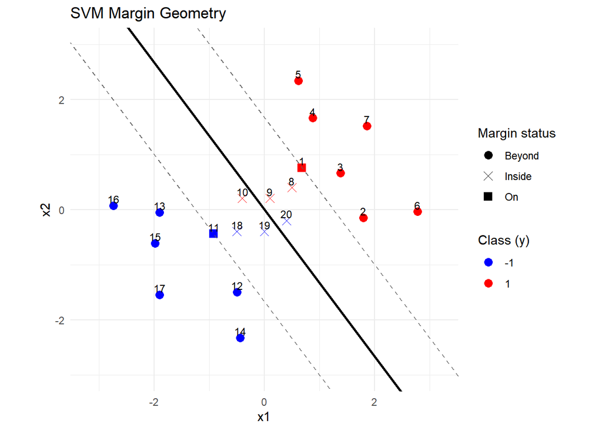

```r
library(ggplot2)
data$obs <- 1:nrow(data)
ggplot(data, aes(x = x1, y = x2)) +
  geom_point(
    aes(color = factor(y), shape = margin_status),
    size = 3
  ) +
  geom_abline(
    slope = -0.8 / 0.6,
    intercept = 0,
    color = "black",
    linewidth = 1
  ) +
  geom_abline(
    slope = -0.8 / 0.6,
    intercept = 1 / 0.6,
    linetype = "dashed",
    color = "gray40"
  ) +
  geom_abline(
    slope = -0.8 / 0.6,
    intercept = -1 / 0.6,
    linetype = "dashed",
    color = "gray40"
  ) +
  geom_text(
    aes(label = obs),
    nudge_y = 0.12,
    size = 3,
    show.legend = FALSE
  ) +
  scale_color_manual(
    values = c("-1" = "blue", "1" = "red"),
    name = "Class (y)"
  ) +
  scale_shape_manual(
    values = c("Inside" = 4, "On" = 15, "Beyond" = 16),
    name = "Margin status"
  ) +
  coord_fixed(
    ratio = 1,
    xlim = c(-3.2, 3.2),
    ylim = c(-3, 3)
  ) +
  labs(
    title = "SVM Margin Geometry",
    x = "x1",
    y = "x2"
  ) +
  theme_minimal()
```

3. Report how many observations are inside, on, and beyond the margin. Which observations are misclassified by this decision rule?

```r
margin_counts <- table(
  factor(
    data$margin_status,
    levels = c("Inside", "On", "Beyond")
  )
)

print(margin_counts)
```

```
Inside     On Beyond
     6      2     12
```

```r
# List misclassified observations
misclassified_obs <- data$obs[data$misclassified]
print(misclassified_obs)
```

```
[1] 10 20
```

```r
# Number of misclassified observations
cat("Number misclassified:", length(misclassified_obs), "\n")
```

```
Number misclassified: 2
```

Use the observation numbers supplied in the data. Set the $x_1$ axis to $[-3.2,3.2]$, set the $x_2$ axis to $[-3,3]$, and use an equal aspect ratio. Do not fit a new classifier for this question.

## Question 2: Margin in four dimensions

Use `margin-geometry-4d.csv` from the combined ZIP, which contains 50 observations with four predictors and class labels $y\in\{-1,1\}$. Consider the linear score

$$f(\mathbf{x})=\beta_0+\mathbf{x}^{\mathsf T}\boldsymbol{\beta},
\qquad
\beta_0=-1,
\quad
\boldsymbol{\beta}=(1,2,-2,4)^{\mathsf T}.$$

1. Project the observations onto the direction of $\boldsymbol{\beta}$ and plot their positions on one axis. Distinguish the two classes and mark the decision boundary. Use the plot to calculate the geometric margin $M$, the distance from the boundary to the closest observation.

```r
data <- read.csv("C:/Users/kates/.vscode/stat432-fall2026/homework/week-08/data/margin-geometry-4d.csv")
# Define beta and beta0
beta0 <- -1
beta <- c(1, 2, -2, 4)

# Extract the four predictors
X <- as.matrix(data[, c("x1", "x2", "x3", "x4")])
y <- data$y

# Calculate the norm of beta
beta_norm <- sqrt(sum(beta^2))

# Project observations onto the direction of beta
data$projection <- as.vector(X %*% beta) / beta_norm

# Calculate the score and functional margin
data$f_x <- beta0 + as.vector(X %*% beta)
data$functional_margin <- y * data$f_x

# Part 1: Calculate the geometric margin
M <- min(abs(data$f_x)) / beta_norm
cat("Geometric margin M:", M, "\n")
```

```
Geometric margin M: 1
```

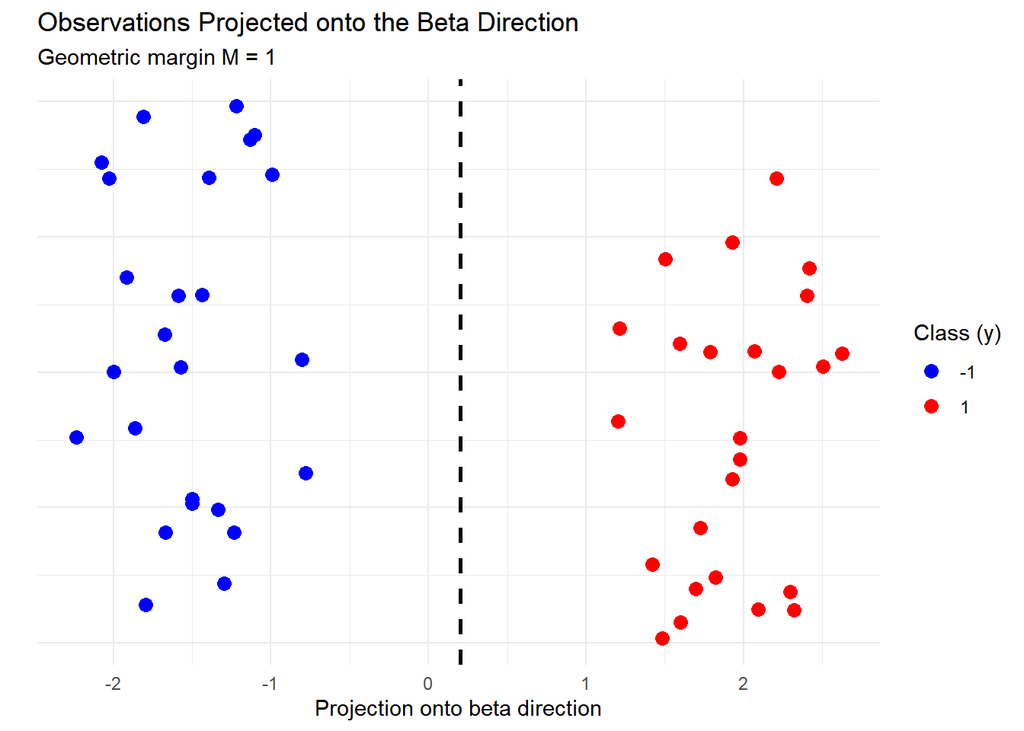

```r
# Plot projected observations on one axis
library(ggplot2)

ggplot(data, aes(x = projection, y = 0, color = factor(y))) +
  geom_point(size = 3, position = position_jitter(height = 0.05)) +
  geom_vline(
    xintercept = -beta0 / beta_norm,
    linetype = "dashed",
    linewidth = 1
  ) +
  scale_color_manual(
    values = c("-1" = "blue", "1" = "red"),
    name = "Class (y)"
  ) +
  labs(
    title = "Observations Projected onto the Beta Direction",
    subtitle = paste("Geometric margin M =", round(M, 4)),
    x = "Projection onto beta direction",
    y = ""
  ) +
  theme_minimal() +
  theme(
    axis.text.y = element_blank(),
    axis.ticks.y = element_blank()
  )
```

2. Express the same decision boundary using the SVM normalization in which the smallest functional margin $y_i f(\mathbf{x}_i)$ is set to 1. What are the corresponding values of $\boldsymbol{\beta}$ and $\beta_0$?

```r
# The smallest functional margin must equal 1
min_functional_margin <- min(data$functional_margin)

beta_svm <- beta / min_functional_margin
beta0_svm <- beta0 / min_functional_margin

cat("Normalized beta0:", beta0_svm, "\n")
```

```
Normalized beta0: -0.2
```

```r
cat("Normalized beta coefficients:\n")
```

```
Normalized beta coefficients:
```

```r
print(beta_svm)
```

```
[1]  0.2  0.4 -0.4  0.8
```

```r
cat(
  "Minimum normalized functional margin:",
  min(data$functional_margin / min_functional_margin),
  "\n"
)
```

```
Minimum normalized functional margin: 1
```

## Question 3: Peer review of a Homework 7 skill

The instructor’s GitHub account, **rqzhu-aide**, will open a **GitHub Issue** in the repository containing your Homework 7 submission. It will link to **one** assigned student’s repository.

1. **Use the skill.** Find the complete skill definition in the assigned student’s Homework 7 report. Copy it without changes into a local `SKILL.md` file in your own folder. You do not need to install it. Give your agent the path to the file and explicitly ask it to follow that skill while analyzing the `SAheart` data, using the response and predictor coding from Homework 7. Provide the necessary data information, but no additional preferences about methods, figures, model selection, or report style. Let the skill direct the analysis.

   Monitor the time, your token use, and your weekly quota while the agent works. If the run is taking too long or using your allowance too quickly, you may send a **steer message** asking the agent to finish immediately, or stop the run and summarize what you observed. A steer message redirects an agent while it is working; learn how to send one in your AI tool before starting.
2. **Write a peer review.** Read the student’s submitted report and what the skill produced in your run. Give a brief overall assessment, followed by **three major items the author could improve**. You may comment on any aspect of the skill or report. For each item, explain what you observed, why it matters, and what you recommend changing. If you stopped the run early, explain where and why. Write the review yourself, without AI assistance.

Overall, the skill worked well. However, one thing I would improve is making the skill more concise. AI knows the general facts about QDA/LDA, so the repeated instructions about fitting preprocessing within folds, preventing data leakage, and refitting the selected model could be made shorter. Another thing I would clarify is how to handle model failures, since there is not a clear instruction on how to compare a candidate that fails in one or more folds with candidates that run successfully. I would also, perhaps just to make things more compact, just combine the table, figure, and results instructions into one checklist to make it easier.

3. **Share your review.** Open a GitHub Issue in the assigned student’s Homework 7 repository containing your review. Copy the same review into your Homework 8 submission report and include a link to the GitHub Issue.

https://github.com/AllyWangYijing/stat432-fall2026/issues/5